# Regression Analysis Week 4 Course Project by Metehan Soysal

## Context & Objective

Using devices such as Jawbone Up, Nike FuelBand, and Fitbit it is now possible to collect a large amount of data about personal activity relatively inexpensively. These type of devices are part of the quantified self movement – a group of enthusiasts who take measurements about themselves regularly to improve their health, to find patterns in their behavior, or because they are tech geeks. One thing that people regularly do is quantify how much of a particular activity they do, but they rarely quantify how well they do it.

In this project, the goal is to use data from accelerometers on the belt, forearm, arm, and dumbell of 6 participants to predict the manner in which they did the exercise.

## Data Processing

### Download & Read Data

The training data for this project are available here:

https://d396qusza40orc.cloudfront.net/predmachlearn/pml-training.csv

The test data are available here:

https://d396qusza40orc.cloudfront.net/predmachlearn/pml-testing.csv

The data for this project come from this source: http://web.archive.org/web/20161224072740/http:/groupware.les.inf.puc-rio.br/har. If you use the document you create for this class for any purpose please cite them as they have been very generous in allowing their data to be used for this kind of assignment.

```r
library(ggplot2); library(caret);library(rattle);library(kernlab)
train_url <- "https://d396qusza40orc.cloudfront.net/predmachlearn/pml-training.csv"
testing_url <- "https://d396qusza40orc.cloudfront.net/predmachlearn/pml-testing.csv"
training_file <- "./pml-training.csv"
testing_file <- "./pml-testing.csv"

if (!file.exists(training_file)) {
        download.file(train_url, destfile=training_file, method="curl")
}
if (!file.exists(testing_file)) {
        download.file(testing_url, destfile=testing_file, method="curl")
}
training_rawdata <- read.csv(training_file)
testing_rawdata <- read.csv(testing_file)
dim(training_rawdata)
```

```
## [1] 19622   160
```

```r
dim(testing_rawdata)
```

```
## [1]  20 160
```

## Prepare the Data

### Cleaning the Data

One of the first thing we will do is to clean the data by removing the X variable which has an ID.

```r
training_rawdata <- training_rawdata[,-1]
testing_rawdata <- testing_rawdata[,-1]
```

Next, we will reduce the variables by using nearZeroVar function.

```r
nzv <- nearZeroVar(training_rawdata)
training_cleandata <- training_rawdata[,-nzv]
testing_cleandata <- testing_rawdata[,-nzv]
dim(training_cleandata)
```

```
## [1] 19622    99
```

```r
dim(testing_cleandata)
```

```
## [1] 20 99
```

Next, we will do variables that has mostly NA value in them.

```r
training_cleandata <- training_cleandata[,colMeans(is.na(training_cleandata)) == 0]
testing_cleandata <- testing_cleandata[,colMeans(is.na(testing_cleandata)) == 0]
dim(training_cleandata)
```

```
## [1] 19622    58
```

```r
dim(testing_cleandata)
```

```
## [1] 20 58
```

Next we will clean the variables that has metadata.

```r
training_cleandata <- training_cleandata[,-c(1:5)]
testing_cleandata <- testing_cleandata[,-c(1:5)]
dim(training_cleandata)
```

```
## [1] 19622    53
```

```r
dim(testing_cleandata)
```

```
## [1] 20 53
```

## Building a Model

### Separating Training Data

We will now separate the training data into 2 slices and use it to train and validate the model.

```r
intrain <- createDataPartition(training_cleandata$classe, p = 0.7, list = FALSE)
sub_train <- training_cleandata[intrain,]
valid_train <- training_cleandata[-intrain,]
```

### Creating the Models

We will be creating 4 models (decision tree, random forest, support vector machines, gradient boosted trees) and test the accuracy of these models by using the sub_train and valid_train data sets before applying this to the testing_cleandata set.

We will use 5-fold cross validation.

```r
control <- trainControl(method = "cv", number = 5, verboseIter = FALSE)
```

#### Model - Decision Tree

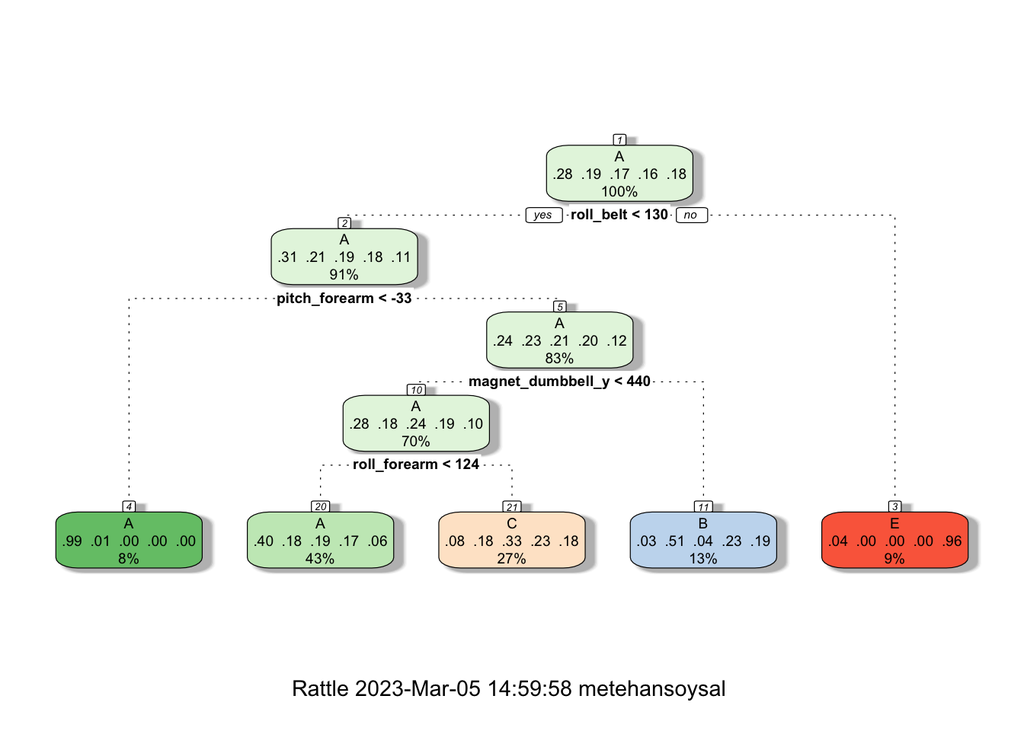

```r
model_dec_tree <- train(classe ~ ., data = sub_train, method = "rpart", trControl = control)
fancyRpartPlot(model_dec_tree$finalModel)
```

Next, we will predict and validate the prediction results.

```r
pred_dec_tree <- predict(model_dec_tree, valid_train)
cm_dec_tree <- confusionMatrix(pred_dec_tree, factor(valid_train$classe))
cm_dec_tree
```

```
## Confusion Matrix and Statistics
##
##           Reference
## Prediction    A    B    C    D    E
##          A 1514  479  475  439  152
##          B   30  386   32  170  135
##          C  107  274  519  355  299
##          D    0    0    0    0    0
##          E   23    0    0    0  496
##
## Overall Statistics
##
##                Accuracy : 0.4953
##                  95% CI : (0.4825, 0.5082)
##     No Information Rate : 0.2845
##     P-Value [Acc > NIR] : < 2.2e-16
##
##                   Kappa : 0.3404
##
##  Mcnemar's Test P-Value : NA
##
## Statistics by Class:
##
##                      Class: A Class: B Class: C Class: D Class: E
## Sensitivity            0.9044  0.33889  0.50585   0.0000  0.45841
## Specificity            0.6331  0.92267  0.78699   1.0000  0.99521
## Pos Pred Value         0.4949  0.51262  0.33398      NaN  0.95568
## Neg Pred Value         0.9434  0.85327  0.88294   0.8362  0.89079
## Prevalence             0.2845  0.19354  0.17434   0.1638  0.18386
## Detection Rate         0.2573  0.06559  0.08819   0.0000  0.08428
## Detection Prevalence   0.5198  0.12795  0.26406   0.0000  0.08819
## Balanced Accuracy      0.7688  0.63078  0.64642   0.5000  0.72681
```

As the result suggests the accuracy of this model is **0.4953271**.

#### Model Random Forest

```r
model_rf <- train(classe ~ ., data = sub_train, method = "rf", trControl = control)
```

Next, we will predict and validate the prediction results.

```r
pred_rf <- predict(model_rf, valid_train)
cm_rf <- confusionMatrix(pred_rf, factor(valid_train$classe))
cm_rf
```

```
## Confusion Matrix and Statistics
##
##           Reference
## Prediction    A    B    C    D    E
##          A 1674    4    0    0    0
##          B    0 1134    4    0    0
##          C    0    1 1021   15    0
##          D    0    0    1  948    4
##          E    0    0    0    1 1078
##
## Overall Statistics
##
##                Accuracy : 0.9949
##                  95% CI : (0.9927, 0.9966)
##     No Information Rate : 0.2845
##     P-Value [Acc > NIR] : < 2.2e-16
##
##                   Kappa : 0.9936
##
##  Mcnemar's Test P-Value : NA
##
## Statistics by Class:
##
##                      Class: A Class: B Class: C Class: D Class: E
## Sensitivity            1.0000   0.9956   0.9951   0.9834   0.9963
## Specificity            0.9991   0.9992   0.9967   0.9990   0.9998
## Pos Pred Value         0.9976   0.9965   0.9846   0.9948   0.9991
## Neg Pred Value         1.0000   0.9989   0.9990   0.9968   0.9992
## Prevalence             0.2845   0.1935   0.1743   0.1638   0.1839
## Detection Rate         0.2845   0.1927   0.1735   0.1611   0.1832
## Detection Prevalence   0.2851   0.1934   0.1762   0.1619   0.1833
## Balanced Accuracy      0.9995   0.9974   0.9959   0.9912   0.9980
```

As the result suggests the accuracy of this model is **0.9949023**.

#### Model Support Vector Machines

```r
model_svm <- train(classe ~ ., data = sub_train, method = "svmLinear", trControl = control)
```

Next, we will predict and validate the prediction results.

```r
pred_svm <- predict(model_svm, valid_train)
cm_svm <- confusionMatrix(pred_svm, factor(valid_train$classe))
cm_svm
```

```
## Confusion Matrix and Statistics
##
##           Reference
## Prediction    A    B    C    D    E
##          A 1543  156   93   62   58
##          B   31  810   99   35  142
##          C   41   66  774   96   71
##          D   56   22   39  723   65
##          E    3   85   21   48  746
##
## Overall Statistics
##
##                Accuracy : 0.781
##                  95% CI : (0.7702, 0.7915)
##     No Information Rate : 0.2845
##     P-Value [Acc > NIR] : < 2.2e-16
##
##                   Kappa : 0.7215
##
##  Mcnemar's Test P-Value : < 2.2e-16
##
## Statistics by Class:
##
##                      Class: A Class: B Class: C Class: D Class: E
## Sensitivity            0.9217   0.7112   0.7544   0.7500   0.6895
## Specificity            0.9124   0.9353   0.9436   0.9630   0.9673
## Pos Pred Value         0.8070   0.7252   0.7385   0.7989   0.8261
## Neg Pred Value         0.9670   0.9310   0.9479   0.9516   0.9326
## Prevalence             0.2845   0.1935   0.1743   0.1638   0.1839
## Detection Rate         0.2622   0.1376   0.1315   0.1229   0.1268
## Detection Prevalence   0.3249   0.1898   0.1781   0.1538   0.1534
## Balanced Accuracy      0.9171   0.8232   0.8490   0.8565   0.8284
```

As the result suggests the accuracy of this model is **0.7809686**.

#### Model Gradient Boosted Trees

```r
model_gbt <- train(classe ~ ., data = sub_train, method = "gbm", trControl = control, verbose = FALSE)
```

Next, we will predict and validate the prediction results.

```r
pred_gbt <- predict(model_gbt, valid_train)
cm_gbt <- confusionMatrix(pred_gbt, factor(valid_train$classe))
cm_gbt
```

```
## Confusion Matrix and Statistics
##
##           Reference
## Prediction    A    B    C    D    E
##          A 1657   39    0    0    2
##          B    9 1068   30    4   11
##          C    2   29  981   26    7
##          D    4    2   15  930   20
##          E    2    1    0    4 1042
##
## Overall Statistics
##
##                Accuracy : 0.9648
##                  95% CI : (0.9598, 0.9694)
##     No Information Rate : 0.2845
##     P-Value [Acc > NIR] : < 2.2e-16
##
##                   Kappa : 0.9555
##
##  Mcnemar's Test P-Value : 4.114e-08
##
## Statistics by Class:
##
##                      Class: A Class: B Class: C Class: D Class: E
## Sensitivity            0.9898   0.9377   0.9561   0.9647   0.9630
## Specificity            0.9903   0.9886   0.9868   0.9917   0.9985
## Pos Pred Value         0.9759   0.9519   0.9388   0.9578   0.9933
## Neg Pred Value         0.9959   0.9851   0.9907   0.9931   0.9917
## Prevalence             0.2845   0.1935   0.1743   0.1638   0.1839
## Detection Rate         0.2816   0.1815   0.1667   0.1580   0.1771
## Detection Prevalence   0.2885   0.1907   0.1776   0.1650   0.1782
## Balanced Accuracy      0.9901   0.9631   0.9715   0.9782   0.9808
```

As the result suggests the accuracy of this model is **0.9648258**.

### Model Results & Selection

Based on the results Random Forest provides the best accuracy with **0.9949023**. We will use this model to predict the Classe for the testing set that was put aside.

```r
pred_test <- predict(model_rf, testing_cleandata)
pred_test
```

```
##  [1] B A B A A E D B A A B C B A E E A B B B
## Levels: A B C D E
```

## Appendix

Plots can be found below.

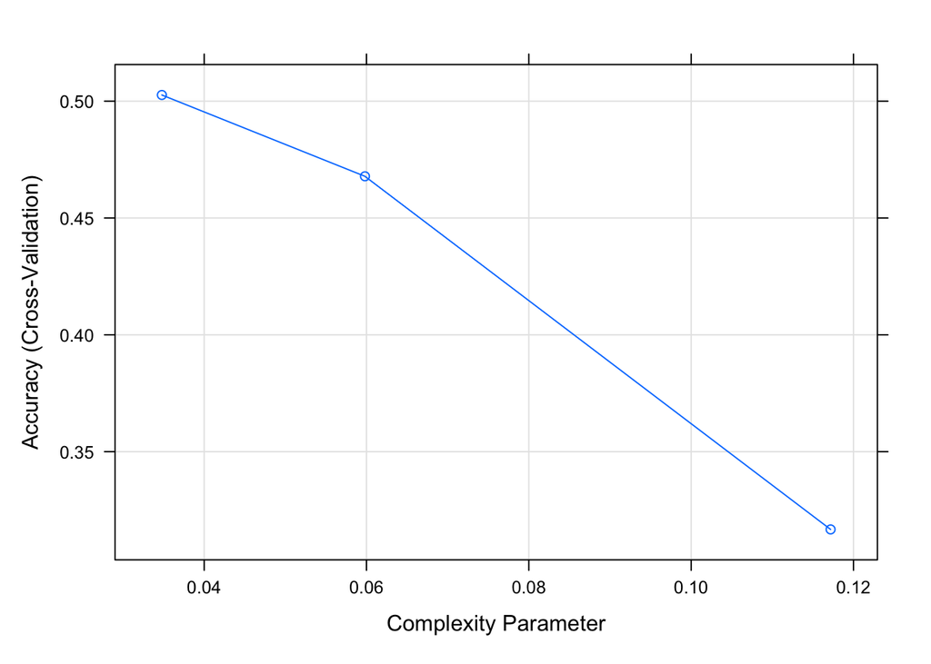

```r
plot(model_dec_tree)
```

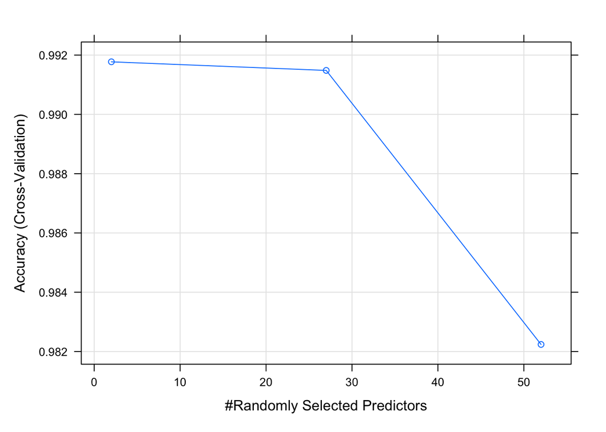

```r
plot(model_rf)
```

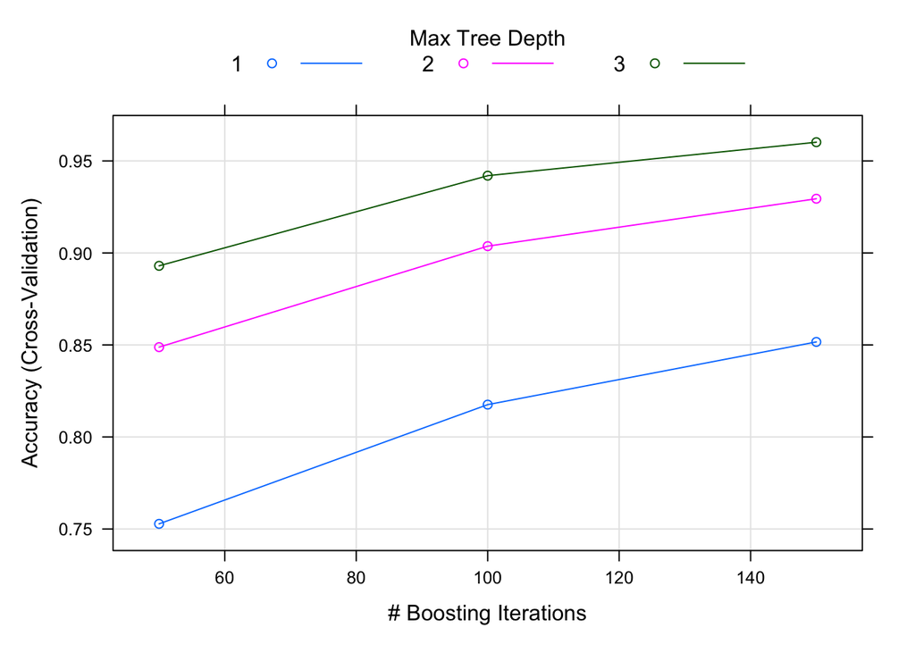

```r
plot(model_gbt)
```